# R Notebook

# Práctica 2

## Carga del Dataset

```r
path = 'heart.csv'
heart <- read.csv(path, row.names=NULL)

structure = str(heart)
```

```
'data.frame':   918 obs. of  12 variables:
 $ Age           : int  40 49 37 48 54 39 45 54 37 48 ...
 $ Sex           : chr  "M" "F" "M" "F" ...
 $ ChestPainType : chr  "ATA" "NAP" "ATA" "ASY" ...
 $ RestingBP     : int  140 160 130 138 150 120 130 110 140 120 ...
 $ Cholesterol   : int  289 180 283 214 195 339 237 208 207 284 ...
 $ FastingBS     : int  0 0 0 0 0 0 0 0 0 0 ...
 $ RestingECG    : chr  "Normal" "Normal" "ST" "Normal" ...
 $ MaxHR         : int  172 156 98 108 122 170 170 142 130 120 ...
 $ ExerciseAngina: chr  "N" "N" "N" "Y" ...
 $ Oldpeak       : num  0 1 0 1.5 0 0 0 0 1.5 0 ...
 $ ST_Slope      : chr  "Up" "Flat" "Up" "Flat" ...
 $ HeartDisease  : int  0 1 0 1 0 0 0 0 1 0 ...
```

## Limpieza de datos

```r
# Datos incompletos
print('Valores NA:')
```

```
[1] "Valores NA:"
```

```r
colSums(is.na(heart))
```

```
           Age            Sex  ChestPainType      RestingBP    Cholesterol      FastingBS     RestingECG          MaxHR ExerciseAngina
             0              0              0              0              0              0              0              0              0
       Oldpeak       ST_Slope   HeartDisease
             0              0              0
```

```r
# Datos redundantes
print('Duplicated rows: ')
```

```
[1] "Duplicated rows: "
```

```r
sum(duplicated(heart))
```

```
[1] 0
```

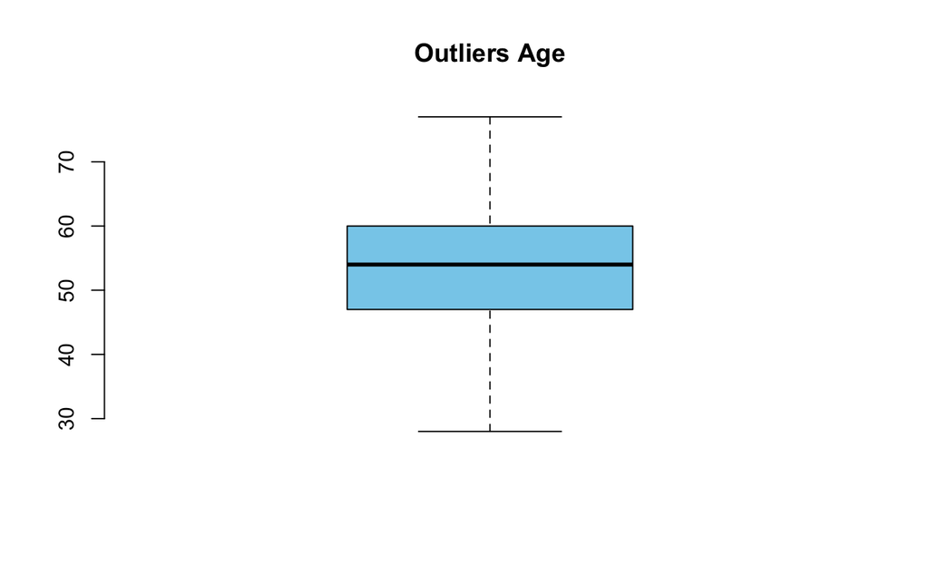

```r
# Gestionar zeros



# Eliminamos valores extremos

box_p<-boxplot(heart$Age, col="skyblue", frame.plot=F, main="Outliers Age")
```

```r
box_p$out
```

```
numeric(0)
```

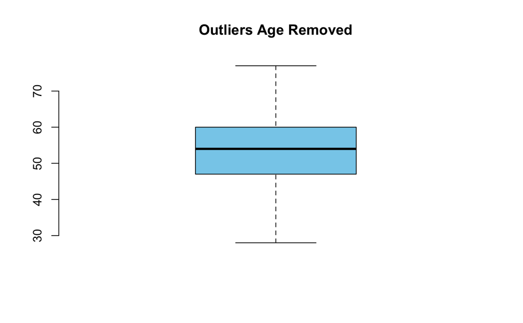

```r
heart_no_outliers<-heart[!(heart$Age %in% box_p$out),]
box_p<-boxplot(heart$Age, col="skyblue", frame.plot=F, main="Outliers Age Removed")
```

```r
box_p$out
```

```
numeric(0)
```

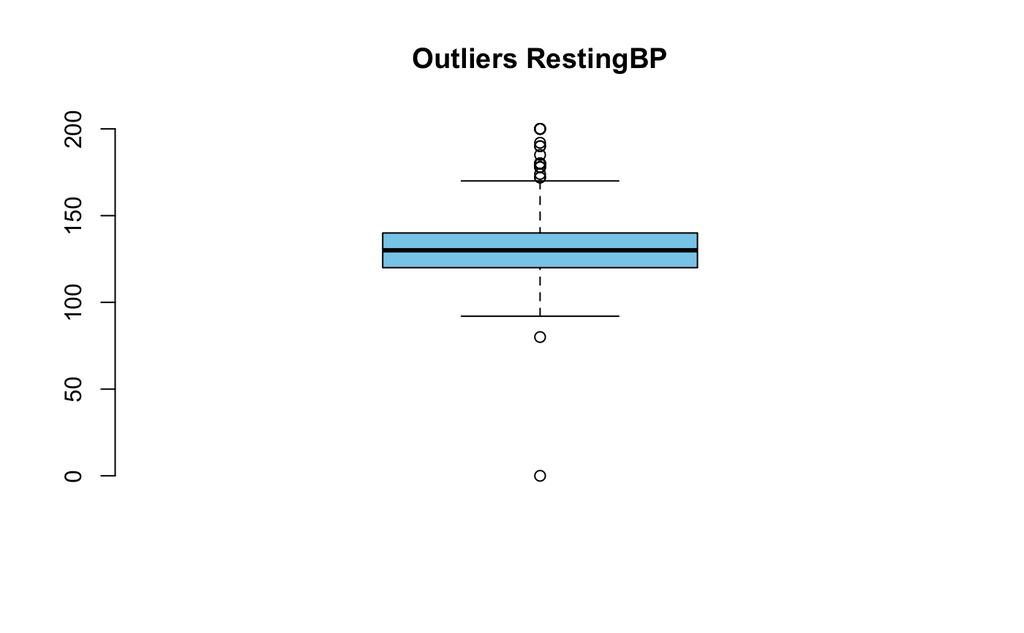

```r
box_p<-boxplot(heart_no_outliers$RestingBP, col="skyblue", frame.plot=F, main="Outliers RestingBP")
```

```r
box_p$out
```

```
 [1] 190 180 180 180 200 180 180 180  80 200 185 200 180 180   0 178 172 180 190 174 178 180 200 192 178 180 180 172
```

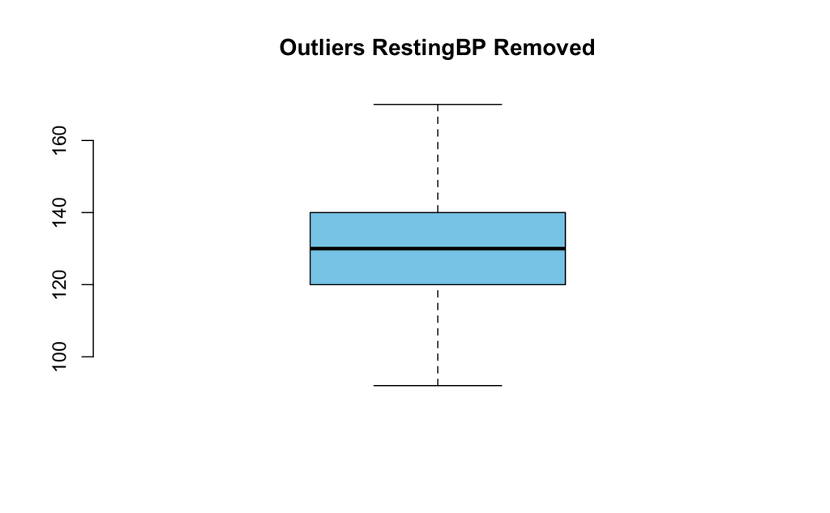

```r
heart_no_outliers<-heart_no_outliers[!(heart_no_outliers$RestingBP %in% box_p$out),]
box_p<-boxplot(heart_no_outliers$RestingBP, col="skyblue", frame.plot=F, main="Outliers RestingBP Removed")
```

```r
box_p$out
```

```
numeric(0)
```

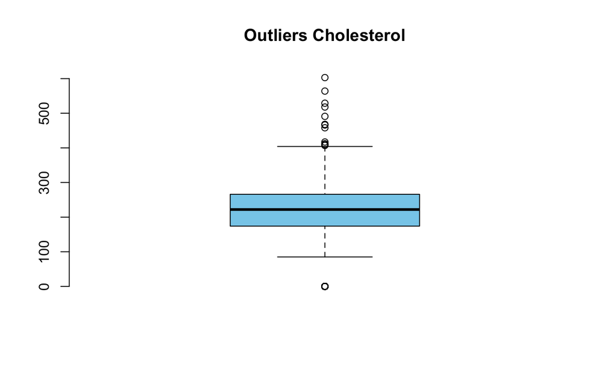

```r
box_p<-boxplot(heart_no_outliers$Cholesterol, col="skyblue", frame.plot=F, main="Outliers Cholesterol")
```

```r
box_p$out
```

```
  [1] 468 518 412 529 466 603 491   0   0   0   0   0   0   0   0   0   0   0   0   0   0   0   0   0   0   0   0   0   0   0   0   0   0
 [34]   0   0   0   0   0   0   0   0   0   0   0   0   0   0   0   0   0   0   0   0   0   0   0   0   0   0   0   0   0   0   0   0   0
 [67]   0   0   0   0   0   0   0   0   0   0   0   0   0   0   0   0   0   0   0   0   0   0   0   0   0   0   0   0   0   0   0   0   0
[100]   0   0   0   0   0   0   0   0   0   0   0   0   0   0   0   0   0   0   0   0   0   0   0   0   0   0   0   0   0   0   0   0   0
[133]   0   0   0   0   0   0   0   0   0   0   0   0   0   0   0   0   0   0   0   0   0   0   0   0   0   0   0   0   0   0   0   0   0
[166] 458   0   0   0   0   0   0 564 407 417 409
```

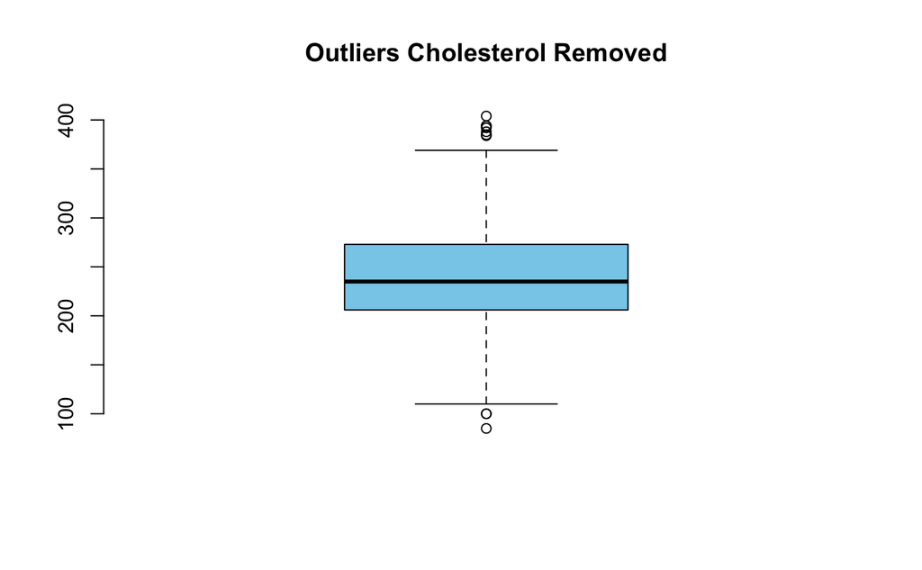

```r
heart_no_outliers<-heart_no_outliers[!(heart_no_outliers$Cholesterol %in% box_p$out),]
box_p<-boxplot(heart_no_outliers$Cholesterol, col="skyblue", frame.plot=F, main="Outliers Cholesterol Removed")
```

```r
box_p$out
```

```
 [1] 100  85 392 388 404 394 100 384 385 394
```

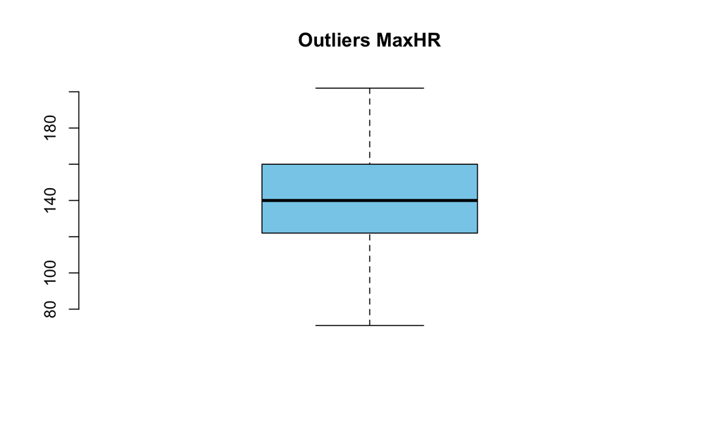

```r
box_p<-boxplot(heart_no_outliers$MaxHR, col="skyblue", frame.plot=F, main="Outliers MaxHR")
```

```r
box_p$out
```

```
numeric(0)
```

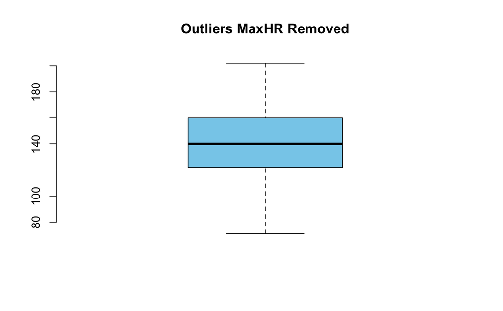

```r
heart_no_outliers<-heart_no_outliers[!(heart_no_outliers$MaxHR %in% box_p$out),]
box_p<-boxplot(heart_no_outliers$MaxHR, col="skyblue", frame.plot=F, main="Outliers MaxHR Removed")
```

```r
box_p$out
```

```
numeric(0)
```

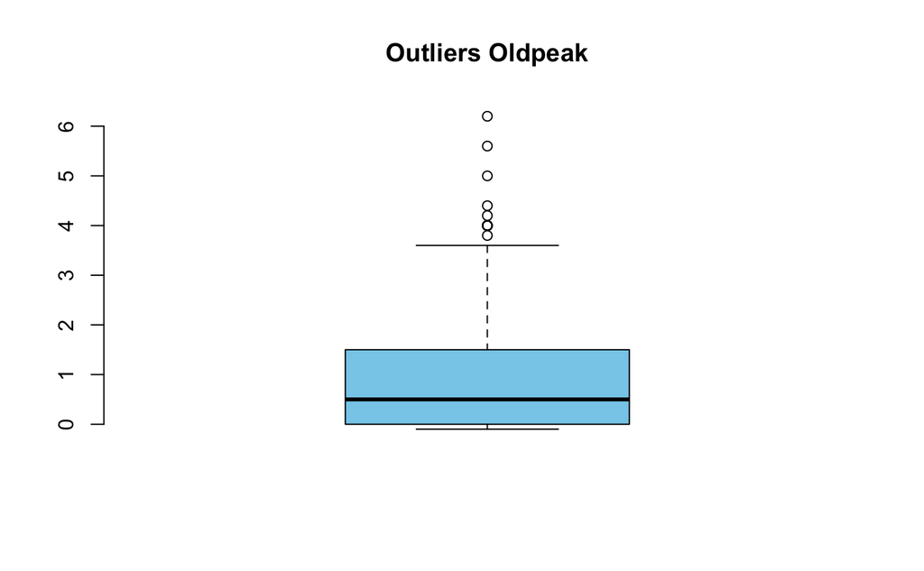

```r
box_p<-boxplot(heart_no_outliers$Oldpeak, col="skyblue", frame.plot=F, main="Outliers Oldpeak")
```

```r
box_p$out
```

```
 [1] 4.0 5.0 4.0 4.0 4.0 4.0 5.6 3.8 4.2 6.2 4.4 4.0
```

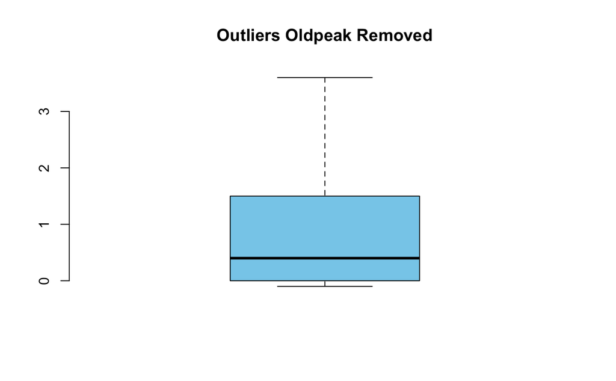

```r
heart_no_outliers<-heart_no_outliers[!(heart_no_outliers$Oldpeak %in% box_p$out),]
box_p<-boxplot(heart_no_outliers$Oldpeak, col="skyblue", frame.plot=F, main="Outliers Oldpeak Removed")
```

```r
box_p$out
```

```
numeric(0)
```

## Análisis de los datos

Contestada en el latex

## Comprobación de la normalidad y homogeneidad

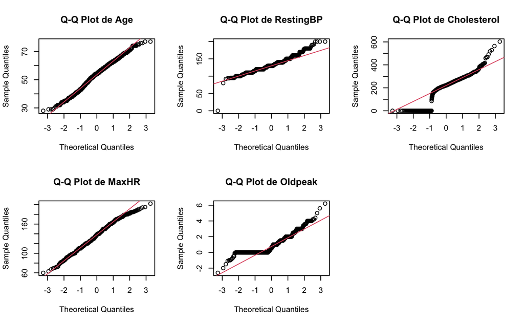

```r
ComX <- heart[, c("Age", "RestingBP", "Cholesterol", "MaxHR", "Oldpeak")]

# plots
par(mfrow = c(2, 3))
for (col in names(ComX)) {
  qqnorm(ComX[[col]], main = paste("Q-Q Plot de", col))
  qqline(ComX[[col]], col = 2)
}
```

## Pruebas estadísticas

```r
x<- na.omit(heart[, c("Age", "RestingBP", "Cholesterol", "MaxHR", "Oldpeak")])


# histogramas
par(mfrow = c(2, 3))
hist(heart$Age, main="Histograma de Edad", xlab="Age", col="lightblue")
hist(heart$RestingBP, main="Histograma de RestingBP", xlab="RestingBP", col="lightblue")
```

```r
hist(heart$Cholesterol, main="Histograma de Cholesterol", xlab="Cholesterol", col="lightblue")
hist(heart$MaxHR, main="Histograma de MaxHR", xlab="MaxHR", col="lightblue")
```

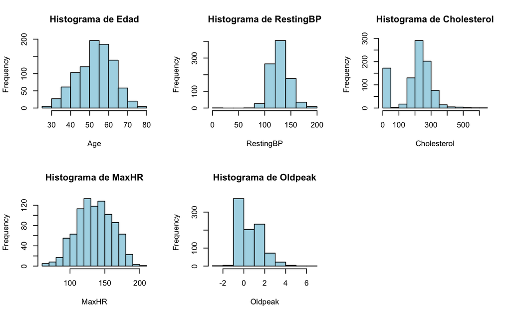

```r
hist(heart$Oldpeak, main="Histograma de Oldpeak", xlab="Oldpeak", col="lightblue")
```

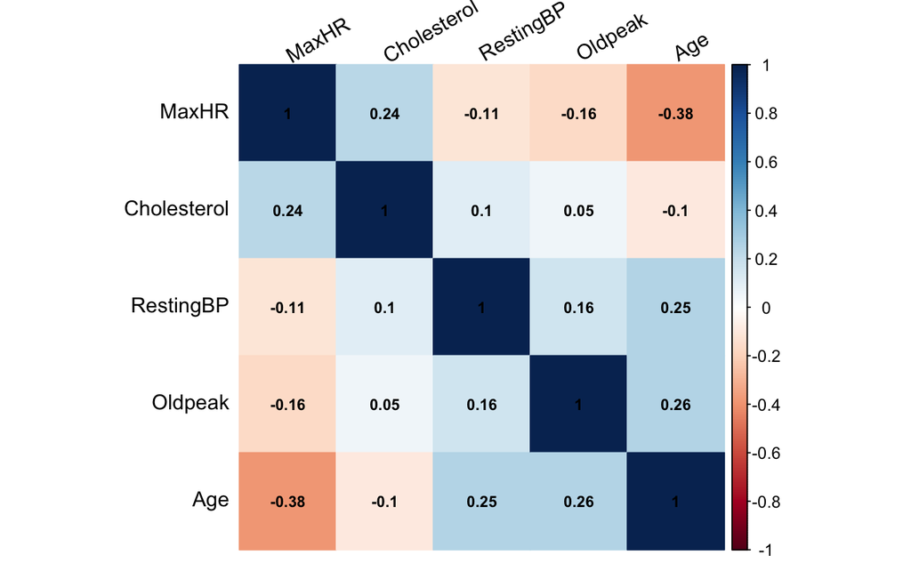

```r
if(!require("corrplot")) install.packages("corrplot"); library("corrplot")

# correlaciones
res<-cor(x)
corrplot(res,method="color",tl.col="black", tl.srt=30, order = "AOE",
number.cex=0.75,sig.level = 0.01, addCoef.col = "black")
```

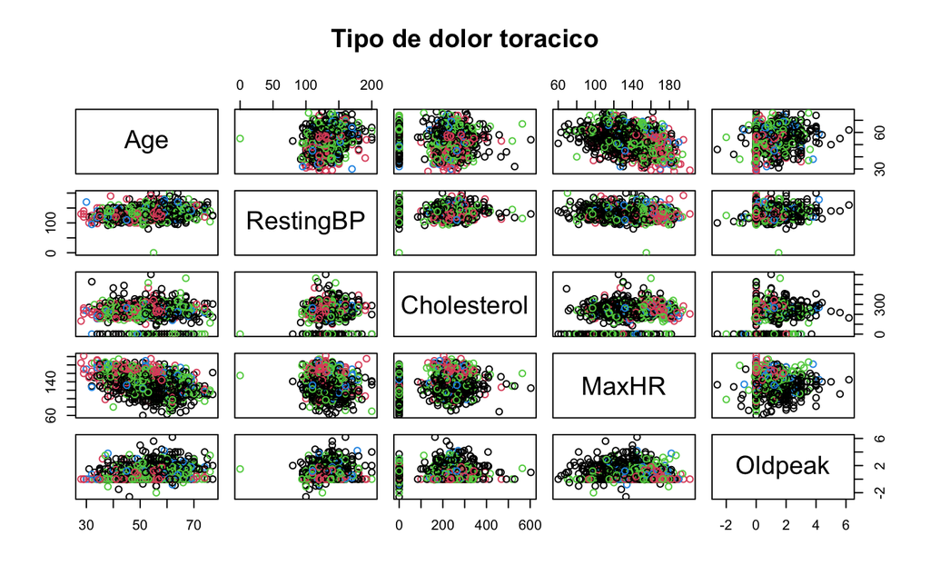

```r
if (!require('ggplot2')) install.packages('ggplot2'); library('ggplot2')


# visualizaciones

# matriz de graficos
plot(x, col=as.factor(heart$ChestPainType), main="Tipo de dolor toracico")
```

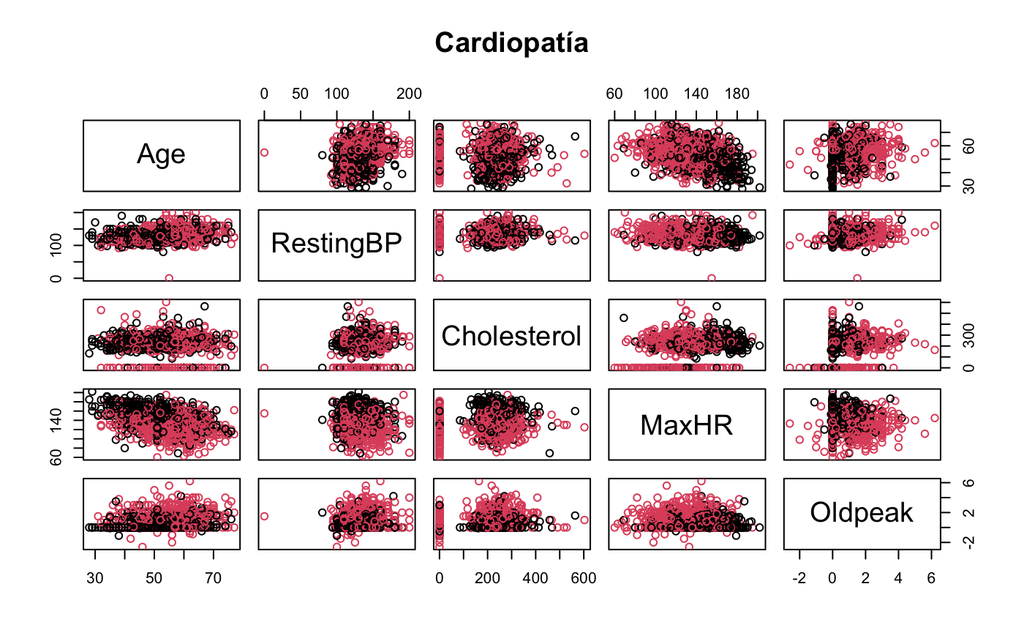

```r
# matriz de graficos
plot(x, col=as.factor(heart$HeartDisease), main="Cardiopatía")
```

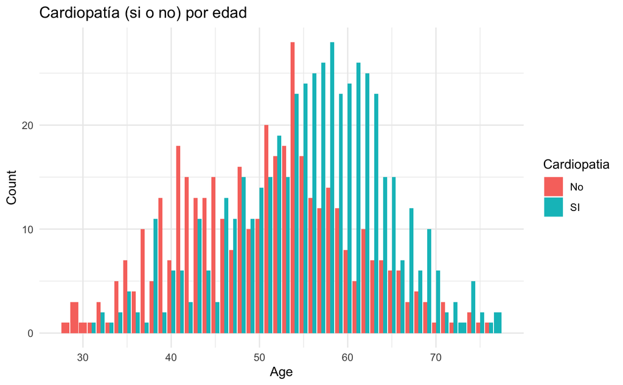

```r
ggplot(heart, aes(x=Age)) +
  geom_bar(aes(fill=factor(HeartDisease)), position="dodge") +
  scale_fill_discrete(name="Cardiopatia", labels=c("No", "SI")) +
  labs(x="Age", y="Count") +
  ggtitle("Cardiopatía (si o no) por edad") +
  theme_minimal()
```

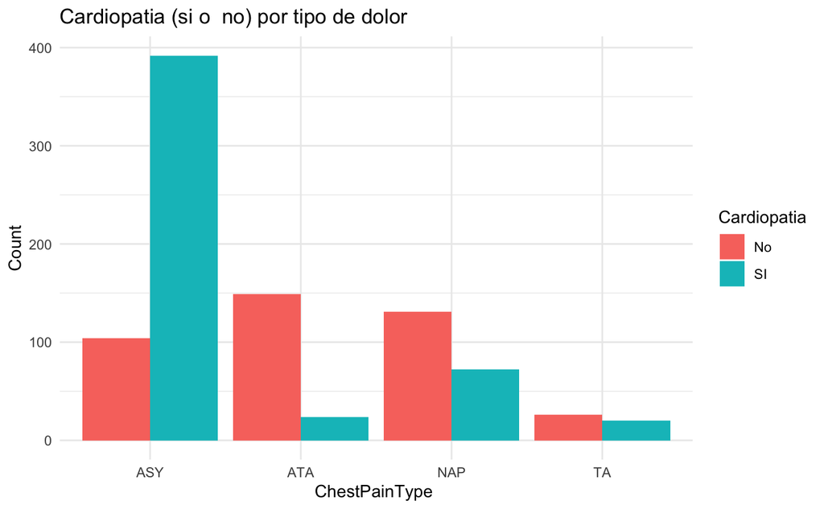

```r
ggplot(heart, aes(x=ChestPainType )) +
  geom_bar(aes(fill=factor(HeartDisease)), position="dodge") +
  scale_fill_discrete(name="Cardiopatia", labels=c("No", "SI")) +
  labs(x="ChestPainType ", y="Count") +
  ggtitle("Cardiopatia (si o  no) por tipo de dolor") +
  theme_minimal()
```

## Predicción

```r
# Conjunto de datos
all_dataset <- na.omit(heart[, c("Age", "RestingBP", "Cholesterol", "MaxHR", "Oldpeak", "HeartDisease")])
indices_entrenamiento <- sample(1:nrow(all_dataset), 0.7 * nrow(all_dataset))
train_dataset <- all_dataset[indices_entrenamiento, ]
test_dataset <- all_dataset[-indices_entrenamiento, ]

# Entrenar el modelo
modelo <- glm(HeartDisease ~ ., data = train_dataset)
predicciones <- predict(modelo, newdata = test_dataset, type = "response")

# Clases (usando un umbral)
umbral <- 0.3
clases_predichas <- ifelse(predicciones > umbral, 1, 0)
precision <- mean(clases_predichas == all_dataset$HeartDisease)
cat("Precisión del modelo:", precision)
```

```
Precisión del modelo: 0.5206972
```

A continuación, se han mostrado los **histogramas** de las diferentes variables numéricas para poder observar sus **frequencias**:

Posteriormente se han visualizado las **correlaciones** entre las diferentes variables numéricas del dataset. Para ello se ha generado la **matriz de correlaciones**, de la cual podemos extraer las siguientes conclusiones:

- Observamos una **correlación positiva** significativa las variables MaxHR y Cholesterol y entre Age y RestingBP. También observamos una correlación positiva, aunque menos significativa, entre las variables RestingBP y Oldpeak y entre RestingBP y Cholesterol. Esto significa que cuando una de las dos variables se incrementa, la otra tiende a incrementarse también.
- Observamos una **correlación negativa** bastante significativa entre Age y MaxHR. También encontramos una correlación negativa, aunque menos significativa, entre las variables MaxHR y RestingBP, entre MaxHR y Oldpeak y entre Cholesterol y Age. Esto significa que cuando una de las dos variables se incrementa, la otra tiende a reducirse.
- Por último, observamos que las variables Oldpeak y Cholesterol están poco correlacionadas.

Por último, se han generado varias **visualizaciones** que nos han permitido entender mejor los datos.

La visualización inicial que hemos creado es una **matriz de gráficos de dispersión**, que representa las interrelaciones entre las distintas variables numéricas de nuestro conjunto de datos. En cada gráfico de esta matriz, los puntos se han coloreado de manera diferenciada para representar las categorías individuales de la variable categórica ‘ChestPainType’ (tipos de dolor torácico). Nuestro objetivo era identificar agrupaciones claras en cada par de variables. Sin embargo, observamos que los puntos están bastante entremezclados, lo que dificulta la clasificación del tipo de dolor torácico basándose únicamente en las variables numéricas.

Posteriormente, hemos elaborado un **gráfico de barras** que muestra el número de casos de cardiopatías y no cardiopatías (pacientes a los que no se les ha diagnosticado una cardiopatía) para cada una de las edades registradas. Observamos que la mayoría de los pacientes a los que no se les ha diagnosticado una cardiopatía se encuentran en el rango de edad de 40 a 60 años (edad media). Por otro lado, la mayoría de los pacientes diagnosticados con una cardiopatía se encuentran en el rango de edad de 50 a 70 años (edad media avanzada).

A continuación, hemos elaborado un segundo **gráfico de barras** que muestra el número de casos de cardiopatías y no cardiopatías (pacientes a los que no se les ha diagnosticado una cardiopatía) para cada uno de los tipos de dolor torácico registrados. Observamos que la mayoría de los pacientes con dolor torácico asintomático (ASY) han sido diagnosticados con una cardiopatía. Sin embargo, para la mayoría de los pacientes con otros tipos de dolores torácicos, como angina típica, angina atípica y dolor no anginoso, no se les ha diagnosticado una cardiopatía. Por lo tanto, concluimos que la mayoría de las cardiopatías no se han manifestado con un dolor previo.

## Conclusión

Se ha comenzado por plantear una **problema analítico** sobre el dataset: identificar los factores que influyen en la probabilidad de que una persona desarrolle una cardiopatía. Por ellos se ha establecido que se trata de una problema de clasificación y se han establecido los objetivos.

Tras establecer el problema, se ha llevado a cabo un **análisis exploratorio** del dataset, que ha contenido un análisis estadístico de este. Hemos estudiado las variables más interesantes, comprobando sus distribuciones, frecuencias, correlaciones y varias visualizaciones.

También hemos podido concluir que hay una correlación entre el tipo de dolor torácico sufrido por el paciente con el diagnóstico de una cardiopatía, concluyendo que en muchos casos el paciente no presentará síntomas..